# Philadelphia Eviction Predicting Model

Author

Daisy, Gab, Johnny, Yiting

Published

May 5, 2026

# 1 SET UP

# 2 Data Cleaning

## 2.1 Eviction Filing Records

```r
# load data (https://evictionlab.org/eviction-tracking/get-the-data/)
eviction_0 <- read.csv(here("data/philadelphia_monthly_2020_2021.csv"))
glimpse(eviction_0)
```

```
Rows: 31,084
Columns: 8
$ type                             <chr> "Census Tract", "Census Tract", "Cens…
$ GEOID                            <chr> "42101000101", "42101000101", "421010…
$ racial_majority                  <chr> "White", "White", "White", "White", "…
$ month                            <chr> "01/2020", "02/2020", "03/2020", "04/…
$ filings_2020                     <int> 0, 0, 0, 0, 0, 0, 0, 0, 1, 0, 1, 0, 0…
$ filings_avg                      <dbl> 2.5, 1.5, 1.5, 1.0, 2.0, 1.0, 2.5, 1.…
$ filings_avg_prepandemic_baseline <dbl> 0.75, 1.00, 1.00, 1.75, 1.75, 2.00, 0…
$ last_updated                     <chr> "", "", "", "", "", "", "", "", "", "…
```

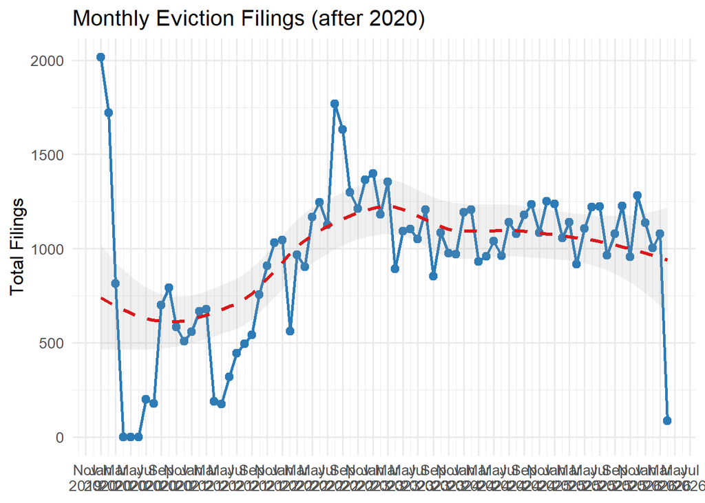

```r
## trends of month
monthly_total <- eviction_0 %>%
  mutate(date = my(month)) %>%
  group_by(date) %>%
  summarise(total_filings = sum(filings_2020, na.rm = TRUE)) %>%
  arrange(date)

ggplot(monthly_total, aes(x = date, y = total_filings)) +
  geom_line(color = "#2c7bb6", linewidth = 1) +
  geom_point(color = "#2c7bb6", size = 2.5) +
  geom_smooth(method = "loess", se = TRUE,
              color = "#d7191c", linetype = "dashed", alpha = 0.15) +
  geom_text(data = monthly_total %>% slice_max(total_filings, n = 1),
            aes(label = paste0(format(date, "%b %Y"), "\n", total_filings)),
            vjust = -1, size = 3.5, color = "#d7191c") +

  scale_x_date(date_breaks = "2 months", date_labels = "%b\n%Y") +
  labs(
    title = "Monthly Eviction Filings (after 2020)",
    x = NULL, y = "Total Filings"
  ) +
  theme_minimal(base_size = 13)
```

**Analysis:** The raw eviction filing data show large pandemic-related fluctuations before 2023, reflecting the disruption caused by COVID-era eviction moratoria, emergency rental assistance, and other temporary housing policies. After March 2023, filings return to a more stable pattern with clearer temporal variation. For this reason, we restrict the analysis to March 2023 through March 2026, so the model is trained on a period with more comparable housing market conditions and more consistent filing policy.

```r
# filter data
results <- list()

## Step 1: original
results[["0_original"]] <- nrow(eviction_0)

## Step 2: date filter
eviction_step1 <- eviction_0 %>%
  filter(between(my(month), my("03/2023"), my("03/2026")))
results[["1_2023Mar_2026Mar"]] <- nrow(eviction_step1)

## Step 3: GEOID != "sealed"
eviction_step2 <- eviction_step1 %>%
  filter(GEOID != "sealed")
results[["2_geoid_not_sealed"]] <- nrow(eviction_step2)

## Step 4: remove tracts where total filings = 0
evict <- eviction_step2 %>%
  group_by(GEOID) %>%
  filter(sum(filings_2020, na.rm = TRUE) != 0) %>%
  ungroup()
results[["3_tract_total_not_0"]] <- nrow(evict)

## Summary table
tibble(
  step = names(results),
  remaining = unlist(results)
) %>%
  mutate(removed = lag(remaining, default = first(remaining)) - remaining)
```

```
# A tibble: 4 × 3
  step                remaining removed
  <chr>                   <int>   <int>
1 0_original              31084       0
2 1_2023Mar_2026Mar       15133   15951
3 2_geoid_not_sealed      15096      37
4 3_tract_total_not_0     14615     481
```

```r
glimpse(evict)
```

```
Rows: 14,615
Columns: 8
$ type                             <chr> "Census Tract", "Census Tract", "Cens…
$ GEOID                            <chr> "42101000101", "42101000101", "421010…
$ racial_majority                  <chr> "White", "White", "White", "White", "…
$ month                            <chr> "03/2023", "04/2023", "05/2023", "06/…
$ filings_2020                     <int> 1, 1, 0, 1, 2, 1, 0, 2, 0, 1, 3, 0, 2…
$ filings_avg                      <dbl> 1.5, 1.0, 2.0, 1.0, 2.5, 1.5, 0.0, 1.…
$ filings_avg_prepandemic_baseline <dbl> 1.00, 1.75, 1.75, 2.00, 0.50, 0.75, 3…
$ last_updated                     <chr> "", "", "", "", "", "", "", "", "", "…
```

```r
evict <- evict %>%
  mutate(
    GEOID = as.character(GEOID),
    month_date = my(month),
    year = year(month_date),
    month_num = month(month_date)
  ) %>%
  dplyr::select(-last_updated)
```

## 2.2 Census and Housing Variables

```r
# Pull renter households and housing cost variables
acs_housing <- get_acs(
  geography = "tract",
  variables = c(
    renters = "B25003_003",
    median_gross_rent = "B25064_001",
    median_household_income = "B19013_001",
    renter_hh_total = "B25070_001",
    rent_30_34 = "B25070_007",
    rent_35_39 = "B25070_008",
    rent_40_49 = "B25070_009",
    rent_50_plus = "B25070_010",
    rent_not_computed = "B25070_011"
  ),
  state = "PA",
  county = "Philadelphia",
  year = 2023,
  geometry = FALSE
)

renters <- acs_housing %>%
  dplyr::select(GEOID, variable, estimate) %>%
  pivot_wider(names_from = variable, values_from = estimate) %>%
  mutate(
    renter_hh_computed = renter_hh_total - rent_not_computed,
    rent_burden_pct = if_else(
      renter_hh_computed > 0,
      ((rent_30_34 + rent_35_39 + rent_40_49 + rent_50_plus) / renter_hh_computed) * 100,
      NA_real_
    )
  ) %>%
  dplyr::select(
    GEOID,
    renters,
    median_gross_rent,
    median_household_income,
    rent_burden_pct
  )

# Join to dataset
evict <- evict %>%
  left_join(renters, by = "GEOID")

# Normaliza filings
evict <- evict %>%
  mutate(
    filings_per_1k_renters = (filings_2020 / renters) * 1000
  )

# Compute tract-level average rate
evict_clean_rate <- evict %>%
  filter(!is.na(renters) & renters > 0)

evict_clean_rate <- evict_clean_rate %>%
  filter(renters > 100)   # adjust threshold
```

# 3 EDA

## 3.1 Filing Distribution

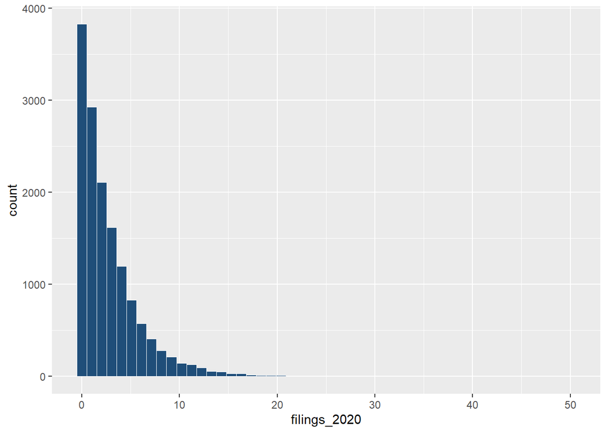

```r
ggplot(evict, aes(x = filings_2020)) +
  geom_histogram(bins = 50, fill = "#1f4e79", color = "white", linewidth = 0.2)
```

**Summary:** Eviction filings are highly skewed and there are a lot of zeros.

## 3.2 Filing Temporal Pattern

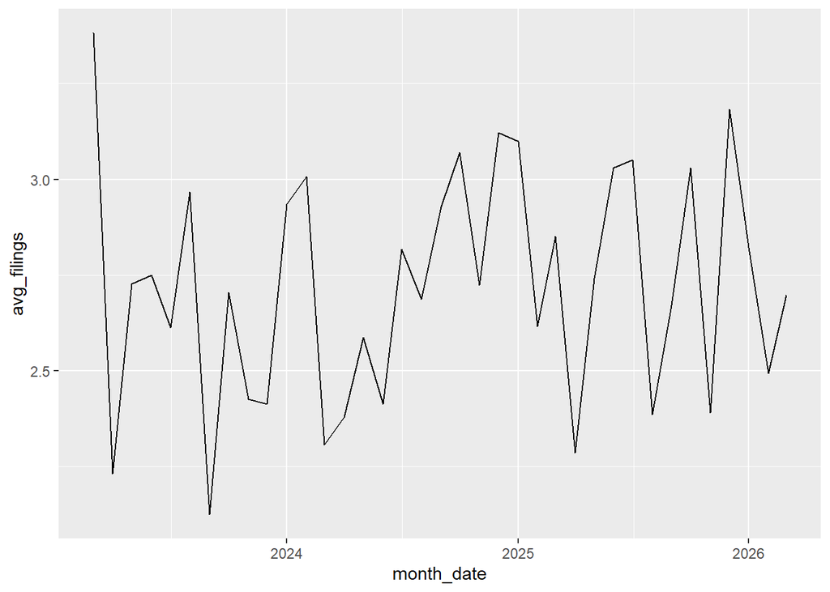

```r
evict %>%
  group_by(month_date) %>%
  summarise(avg_filings = mean(filings_2020, na.rm = TRUE)) %>%
  ggplot(aes(x = month_date, y = avg_filings)) +
  geom_line()
```

**Summary:** There is no strong long-term trend in the filing data and very high month-to-month volatility.

## 3.3 Filing Spatial Pattern

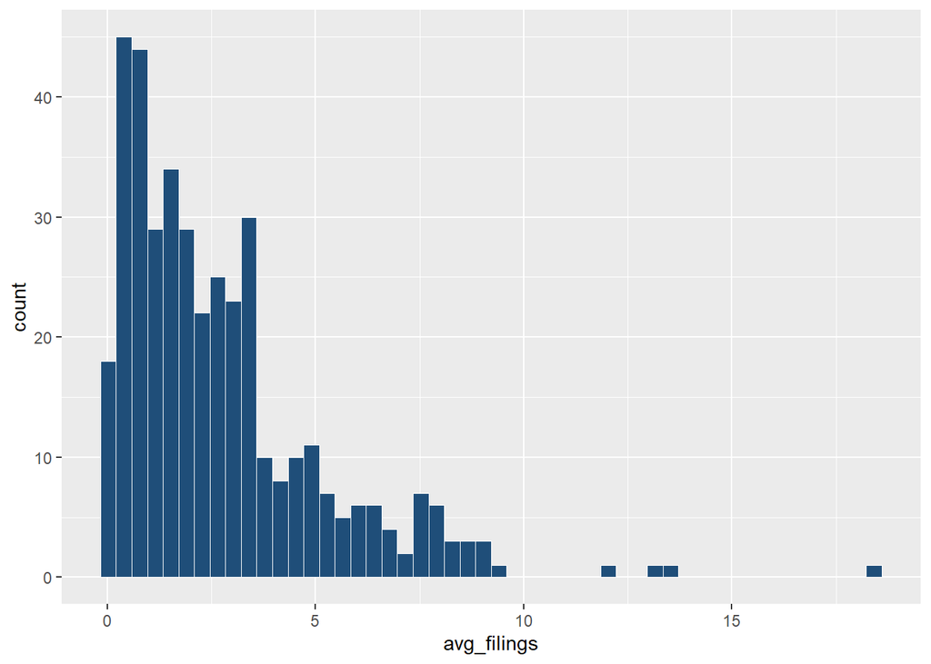

```r
evict %>%
  group_by(GEOID) %>%
  summarise(avg_filings = mean(filings_2020, na.rm = TRUE)) %>%
  ggplot(aes(x = avg_filings)) +
  geom_histogram(bins = 50, fill = "#1f4e79", color = "white", linewidth = 0.2)
```

```r
top10 <- evict %>%
  group_by(GEOID) %>%
  summarise(total = sum(filings_2020, na.rm = TRUE)) %>%
  arrange(desc(total)) %>%
  head(10) # Top 10 census tracts with the most filings

top10
```

```
# A tibble: 10 × 2
   GEOID       total
   <chr>       <int>
 1 42101024000   681
 2 42101036100   504
 3 42101021800   488
 4 42101030100   445
 5 42101020800   346
 6 42101026800   340
 7 42101014000   331
 8 42101023800   329
 9 42101025200   325
10 42101012100   322
```

```r
top10_rate <- evict_clean_rate %>%
  group_by(GEOID) %>%
  summarise(
    avg_rate = mean(filings_per_1k_renters, na.rm = TRUE),
    total_filings = sum(filings_2020, na.rm = TRUE),
    renters = first(renters),
    .groups = "drop"
  ) %>%
  arrange(desc(avg_rate)) %>%
  slice(1:10)

top10_rate
```

```
# A tibble: 10 × 4
   GEOID       avg_rate total_filings renters
   <chr>          <dbl>         <int>   <dbl>
 1 42101036100     33.2           504     410
 2 42101038900     15.7           221     380
 3 42101036201     15.4           283     498
 4 42101005400     13.9           230     448
 5 42101038200     13.8           152     298
 6 42101028000     12.6           251     539
 7 42101035602     12.3            68     149
 8 42101039002     12.0            65     146
 9 42101024000     11.6           681    1583
10 42101027200     11.5           277     650
```

```r
# Find common tracts as policy hotspots
hotspot <- intersect(top10$GEOID, top10_rate$GEOID)
hotspot
```

```
[1] "42101024000" "42101036100"
```

```r
# Build tract-level averages
tract_summary <- evict %>%
  filter(!is.na(GEOID)) %>%
  group_by(GEOID) %>%
  summarise(
    avg_filings = mean(filings_2020, na.rm = TRUE),
    avg_rate_1k = mean(filings_per_1k_renters, na.rm = TRUE),
    total_filings = sum(filings_2020, na.rm = TRUE),
    renters = first(renters),
    .groups = "drop"
  ) %>%
  filter(!is.na(avg_filings), !is.na(avg_rate_1k))

# Download Philadelphia tract geometry
phl_tracts <- get_acs(
  geography = "tract",
  variables = "B01003_001",
  state = "PA",
  county = "Philadelphia",
  year = 2023,
  geometry = TRUE
) %>%
  dplyr::select(GEOID, geometry)
```

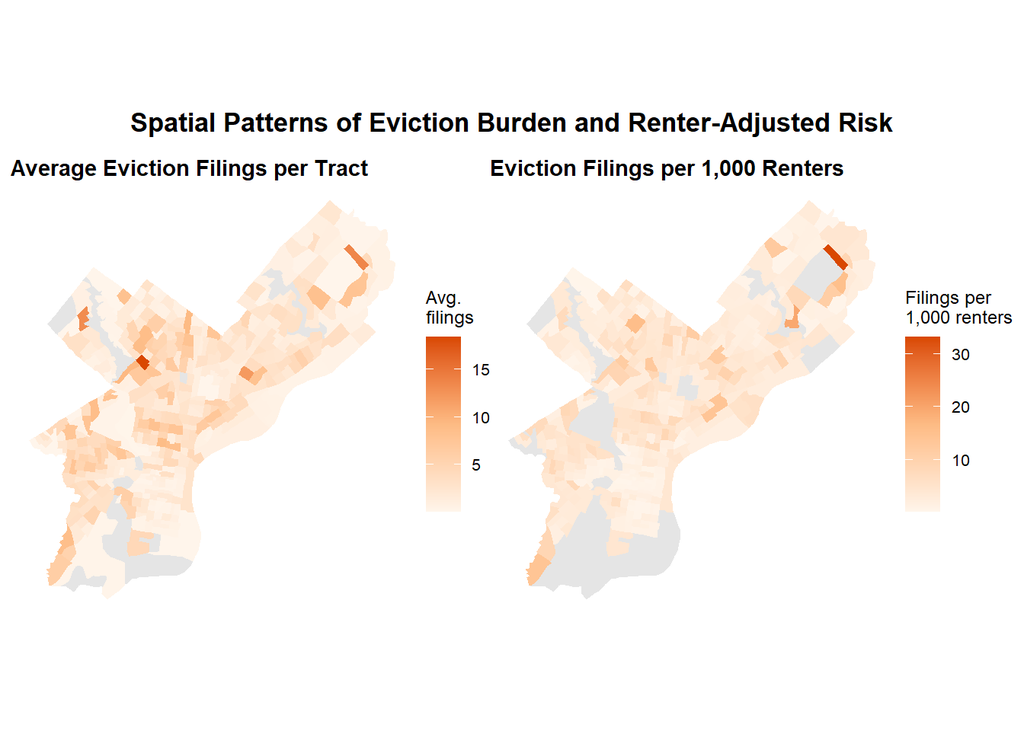

```r
# Join summary data to tract geometry
tract_map <- phl_tracts %>%
  left_join(tract_summary, by = "GEOID")

# Shared orange color palette
orange_low  <- "#fff5eb"
orange_mid  <- "#fdbb84"
orange_high <- "#d94801"

# Map 1: Average filings per tract
map_avg_filings <- ggplot(tract_map) +
  geom_sf(aes(fill = avg_filings), color = NA) +
  scale_fill_gradientn(
    colours = c(orange_low, orange_mid, orange_high),
    name = "Avg.\nfilings",
    na.value = "grey90"
  ) +
  labs(title = "Average Eviction Filings per Tract") +
  theme_void() +
  theme(
    plot.title = element_text(size = 11, face = "bold"),
    legend.title = element_text(size = 9),
    legend.text = element_text(size = 8)
  )

# Map 2: Filings per 1,000 renters
map_rate <- ggplot(tract_map) +
  geom_sf(aes(fill = avg_rate_1k), color = NA) +
  scale_fill_gradientn(
    colours = c(orange_low, orange_mid, orange_high),
    name = "Filings per\n1,000 renters",
    na.value = "grey90"
  ) +
  labs(title = "Eviction Filings per 1,000 Renters") +
  theme_void() +
  theme(
    plot.title = element_text(size = 11, face = "bold"),
    legend.title = element_text(size = 9),
    legend.text = element_text(size = 8)
  )

# Combine maps side by side
map_avg_filings + map_rate +
  plot_annotation(
    title = "Spatial Patterns of Eviction Burden and Renter-Adjusted Risk",
    theme = theme(
      plot.title = element_text(size = 13, face = "bold", hjust = 0.5)
    )
  )
```

**Summary:** There are a few tracts that have very high filing records. By finding the top 10 census tracts with highest filing records and top 10 census tracts with highest filing record concentration, we identify two high risk census tracts that appear in both lists as rental assistance policy hotspots.

## 3.4 Filing Dynamics

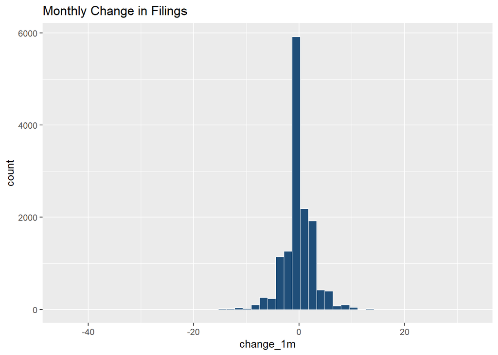

```r
evict <- evict %>%
  arrange(GEOID, month_date) %>%
  group_by(GEOID)

# 1 month lag
evict <- evict %>%
  mutate(
    lag_1m = lag(filings_2020, 1)
  )

# Quarter lag
evict <- evict %>%
  mutate(
    lag_3m = lag(filings_2020, 3)
  )

# Create change variables
evict <- evict %>%
  mutate(
    change_1m = filings_2020 - lag_1m,
    change_3m = filings_2020 - lag_3m
  )

# Visualize 1 month change
ggplot(evict, aes(x = change_1m)) +
  geom_histogram(bins = 50, fill = "#1f4e79", color = "white", linewidth = 0.2) +
  labs(title = "Monthly Change in Filings")
```

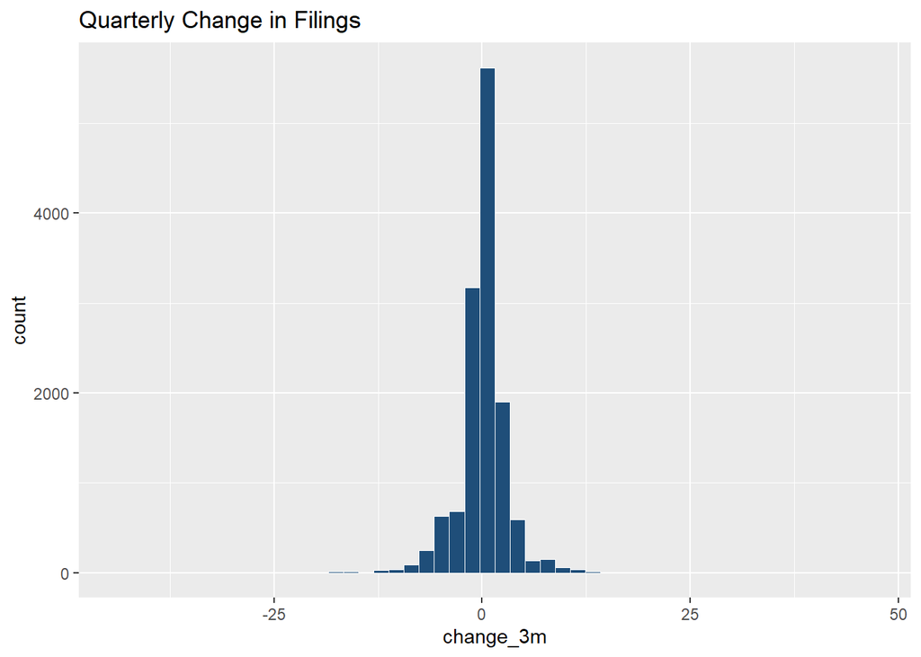

```r
# Visualize quarterly change
ggplot(evict, aes(x = change_3m)) +
  geom_histogram(bins = 50, fill = "#1f4e79", color = "white", linewidth = 0.2) +
  labs(title = "Quarterly Change in Filings")
```

**Summary:** Both monthly and quarterly change have symmetrical distribution. Eviction filings are not consistently increasing or decreasing. Changes in eviction activity fluctuate around a stable baseline rather than showing persistent growth or decline. This suggests that recent lag components of filings are strong predictors for future risks.

## 3.5 Racial Pattern

```r
evict %>%
  group_by(racial_majority) %>%
  summarise(avg_filings = mean(filings_2020, na.rm = TRUE))
```

```
# A tibble: 4 × 2
  racial_majority avg_filings
  <chr>                 <dbl>
1 Black                  3.80
2 Hispanic               2.63
3 Other                  2.60
4 White                  1.70
```

**Summary:** Black-majority neighborhoods have substantially higher average eviction filings. Even after adjusting for renter population, eviction activity remains higher in Black-majority neighborhoods, suggesting structural disparities in housing stability.

# 4 Modeling

## 4.1 Prediction Target

**Analysis:** The prediction task is to forecast census-tract-level eviction filings at monthly and quarterly time scales. We evaluate both count prediction and high-risk tract classification so the model can support short-term rental assistance targeting while still checking whether it identifies the highest-risk places.

```r
library(broom)

score_model <- function(actual, predicted) {
  tibble(
    MAE = mean(abs(actual - predicted), na.rm = TRUE),
    RMSE = sqrt(mean((actual - predicted)^2, na.rm = TRUE)),
    Correlation = cor(actual, predicted, use = "complete.obs")
  )
}

classification_scores <- function(data, truth, pred) {
  tp <- sum(data[[truth]] == 1 & data[[pred]] == 1, na.rm = TRUE)
  fp <- sum(data[[truth]] == 0 & data[[pred]] == 1, na.rm = TRUE)
  fn <- sum(data[[truth]] == 1 & data[[pred]] == 0, na.rm = TRUE)
  tn <- sum(data[[truth]] == 0 & data[[pred]] == 0, na.rm = TRUE)

  tibble(
    Accuracy = (tp + tn) / (tp + tn + fp + fn),
    Precision = ifelse(tp + fp == 0, NA, tp / (tp + fp)),
    Recall = ifelse(tp + fn == 0, NA, tp / (tp + fn)),
    F1 = ifelse(
      (tp + fp) == 0 | (tp + fn) == 0,
      NA_real_,
      2 * ((tp / (tp + fp)) * (tp / (tp + fn))) / ((tp / (tp + fp)) + (tp / (tp + fn)))
    )
  )
}

evaluate_models <- function(data, split_name, model_specs, baseline_var) {
  bind_rows(lapply(names(model_specs), function(model_name) {
    spec <- model_specs[[model_name]]

    predicted <- if (!is.null(spec$type) && spec$type == "baseline") {
      pmax(data[[baseline_var]], 0)
    } else {
      predict(spec$model, newdata = data, type = "response")
    }

    predicted <- pmax(predicted, 0)

    score_model(data$filings_next, predicted) %>%
      mutate(model = model_name, split = split_name)
  }))
}
```

## 4.2 Monthly Models

```r
monthly_model_data <- evict %>%
  ungroup() %>%
  arrange(GEOID, month_date) %>%
  group_by(GEOID) %>%
  mutate(
    filings_next = lead(filings_2020, 1),
    filings_next_per_1k_renters = lead(filings_per_1k_renters, 1),
    lag_2m = lag(filings_2020, 2),
    lag_12m = lag(filings_2020, 12),
    rolling_mean_3m = (lag_1m + lag_2m + lag_3m) / 3
  ) %>%
  ungroup() %>%
  mutate(
    racial_majority = factor(racial_majority),
    month_factor = factor(month_num, levels = 1:12, labels = month.abb)
  ) %>%
  filter(
    !is.na(filings_next),
    !is.na(lag_1m),
    !is.na(lag_2m),
    !is.na(lag_3m),
    !is.na(lag_12m),
    !is.na(renters),
    !is.na(median_gross_rent),
    !is.na(median_household_income),
    !is.na(rent_burden_pct),
    renters > 0
  )

monthly_split_lookup <- tibble(
  month_date = sort(unique(monthly_model_data$month_date))
) %>%
  mutate(
    data_split = case_when(
      month_date <= ymd("2025-02-01") ~ "Train",
      month_date <= ymd("2025-08-01") ~ "Validation",
      TRUE ~ "Test"
    )
  )

monthly_model_data <- monthly_model_data %>%
  left_join(monthly_split_lookup, by = "month_date")

monthly_train <- monthly_model_data %>% filter(data_split == "Train")
monthly_validation <- monthly_model_data %>% filter(data_split == "Validation")
monthly_test <- monthly_model_data %>% filter(data_split == "Test")
```

```r
monthly_model_1 <- MASS::glm.nb(
  filings_next ~ lag_1m + offset(log(renters)),
  data = monthly_train
)

monthly_model_2 <- MASS::glm.nb(
  filings_next ~ lag_1m + lag_3m + change_1m + rolling_mean_3m + offset(log(renters)),
  data = monthly_train
)

monthly_model_3 <- MASS::glm.nb(
  filings_next ~ lag_1m + lag_3m + change_1m + rolling_mean_3m +
    filings_avg + filings_avg_prepandemic_baseline +
    offset(log(renters)),
  data = monthly_train
)

monthly_model_4 <- MASS::glm.nb(
  filings_next ~ lag_1m + lag_3m + change_1m + rolling_mean_3m +
    filings_avg + filings_avg_prepandemic_baseline +
    racial_majority + month_factor +
    offset(log(renters)),
  data = monthly_train
)

monthly_model_5 <- MASS::glm.nb(
  filings_next ~ lag_1m + lag_3m + change_1m + rolling_mean_3m +
    filings_avg + filings_avg_prepandemic_baseline +
    racial_majority + month_factor +
    median_gross_rent + median_household_income + rent_burden_pct +
    offset(log(renters)),
  data = monthly_train
)

monthly_enhanced_baseline <- lm(
  filings_next ~ lag_1m + lag_12m,
  data = monthly_train
)

monthly_rolling_baseline <- lm(
  filings_next ~ lag_1m + lag_12m + rolling_mean_3m,
  data = monthly_train
)

monthly_model_specs <- list(
  "Model 0: Baseline" = list(type = "baseline"),
  "Model 0b: + lag_12m baseline" = list(model = monthly_enhanced_baseline),
  "Model 0c: + rolling_mean_3m baseline" = list(model = monthly_rolling_baseline),
  "Model 1: lag_1m" = list(model = monthly_model_1),
  "Model 2: + dynamic terms" = list(model = monthly_model_2),
  "Model 3: + historical baselines" = list(model = monthly_model_3),
  "Model 4: + race and seasonality" = list(model = monthly_model_4),
  "Model 5: + rent and income" = list(model = monthly_model_5)
)
```

```r
monthly_scores <- bind_rows(
  evaluate_models(monthly_validation, "Validation", monthly_model_specs, "lag_1m"),
  evaluate_models(monthly_test, "Test", monthly_model_specs, "lag_1m")
) %>%
  mutate(scale = "Monthly")

monthly_scores %>%
  mutate(across(c(MAE, RMSE, Correlation), round, 3)) %>%
  dplyr::select(scale, split, model, MAE, RMSE, Correlation) %>%
  kable(caption = "Monthly Forecast Performance as Variables Are Added Step by Step") %>%
  kable_styling(bootstrap_options = c("striped", "hover"))
```

Monthly Forecast Performance as Variables Are Added Step by Step

| scale | split | model | MAE | RMSE | Correlation |
| --- | --- | --- | --- | --- | --- |
| Monthly | Validation | Model 0: Baseline | 1.924 | 2.901 | 0.614 |
| Monthly | Validation | Model 0b: + lag_12m baseline | 1.719 | 2.435 | 0.662 |
| Monthly | Validation | Model 0c: + rolling_mean_3m baseline | 1.622 | 2.310 | 0.703 |
| Monthly | Validation | Model 1: lag_1m | 2.180 | 3.968 | 0.530 |
| Monthly | Validation | Model 2: + dynamic terms | 2.260 | 6.016 | 0.521 |
| Monthly | Validation | Model 3: + historical baselines | 2.045 | 3.735 | 0.600 |
| Monthly | Validation | Model 4: + race and seasonality | 1.960 | 3.512 | 0.606 |
| Monthly | Validation | Model 5: + rent and income | 1.983 | 3.679 | 0.599 |
| Monthly | Test | Model 0: Baseline | 1.991 | 3.030 | 0.578 |
| Monthly | Test | Model 0b: + lag_12m baseline | 1.752 | 2.535 | 0.645 |
| Monthly | Test | Model 0c: + rolling_mean_3m baseline | 1.657 | 2.441 | 0.678 |
| Monthly | Test | Model 1: lag_1m | 2.223 | 5.146 | 0.382 |
| Monthly | Test | Model 2: + dynamic terms | 2.280 | 5.370 | 0.502 |
| Monthly | Test | Model 3: + historical baselines | 2.112 | 3.924 | 0.584 |
| Monthly | Test | Model 4: + race and seasonality | 2.125 | 4.096 | 0.601 |
| Monthly | Test | Model 5: + rent and income | 2.137 | 4.265 | 0.594 |

**Summary:** We first evaluate monthly forecasting performance using held-out validation and test data. MAE and RMSE capture the size of prediction error, while correlation indicates whether the models preserve the relative ranking of tracts by future eviction risk. Across the monthly models, the enhanced baseline performs best out-of-sample, suggesting that recent filing history and short-term persistence contain more predictive information than the addition of broader structural covariates alone.

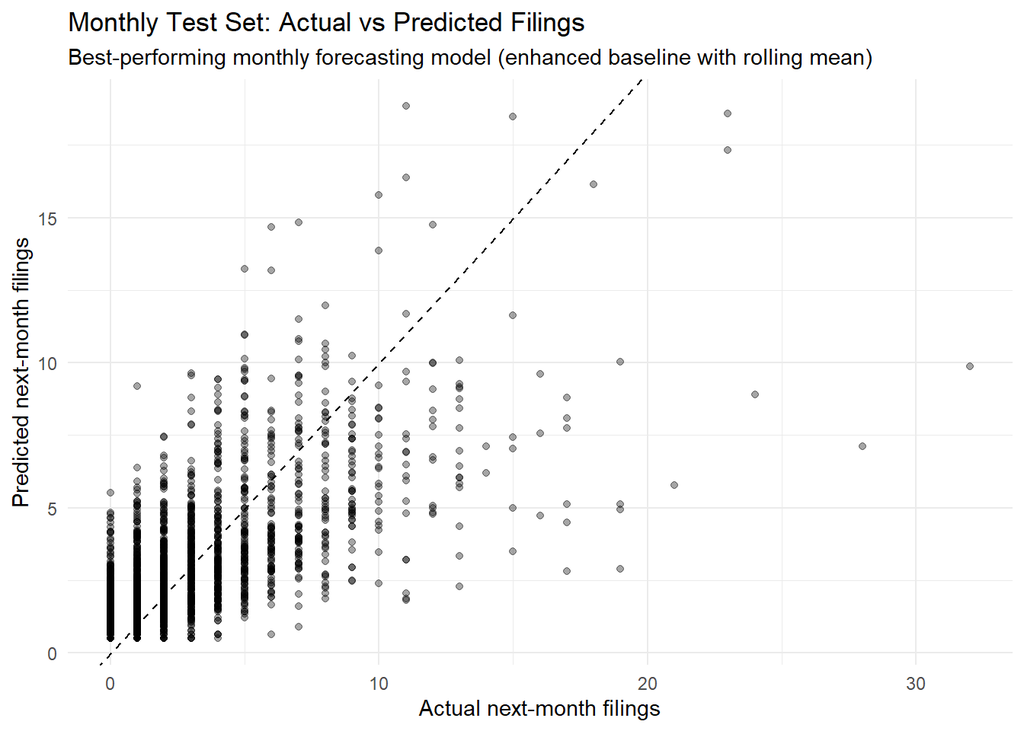

```r
monthly_test_plot_data <- monthly_test %>%
  mutate(
    pred_best = predict(monthly_rolling_baseline, newdata = monthly_test)
  ) %>%
  mutate(
    pred_best = pmax(pred_best, 0)
  )

ggplot(monthly_test_plot_data, aes(x = filings_next, y = pred_best)) +
  geom_point(alpha = 0.35) +
  geom_abline(slope = 1, intercept = 0, linetype = "dashed") +
  labs(
    title = "Monthly Test Set: Actual vs Predicted Filings",
    subtitle = "Best-performing monthly forecasting model (enhanced baseline with rolling mean)",
    x = "Actual next-month filings",
    y = "Predicted next-month filings"
  ) +
  theme_minimal()
```

**Summary:** The monthly actual-versus-predicted plot shows that the preferred monthly forecasting model captures the general tract-level pattern reasonably well, although predicted values appear to compress the upper tail. This suggests that the model is better at tracking moderate variation than at fully capturing the highest-filing tracts.

```r
tidy(monthly_model_5, conf.int = TRUE, exponentiate = TRUE) %>%
  filter(term != "(Intercept)") %>%
  dplyr::select(term, estimate, conf.low, conf.high, p.value) %>%
  arrange(desc(estimate)) %>%
  mutate(across(c(estimate, conf.low, conf.high, p.value), round, 3)) %>%
  head(15) %>%
  kable(
    caption = "Monthly Negative Binomial Model Coefficients (Incidence Rate Ratios)",
    col.names = c("Term", "IRR", "Lower CI", "Upper CI", "p-value")
  ) %>%
  kable_styling(bootstrap_options = c("striped", "hover"))
```

Monthly Negative Binomial Model Coefficients (Incidence Rate Ratios)

| Term | IRR | Lower CI | Upper CI | p-value |
| --- | --- | --- | --- | --- |
| month_factorSep | 1.382 | 1.213 | 1.575 | 0.000 |
| month_factorNov | 1.323 | 1.161 | 1.508 | 0.000 |
| month_factorJun | 1.270 | 1.113 | 1.450 | 0.000 |
| month_factorDec | 1.259 | 1.105 | 1.435 | 0.000 |
| month_factorAug | 1.234 | 1.082 | 1.408 | 0.001 |
| month_factorJul | 1.180 | 1.033 | 1.347 | 0.013 |
| month_factorFeb | 1.179 | 1.033 | 1.345 | 0.013 |
| month_factorApr | 1.140 | 0.997 | 1.303 | 0.052 |
| month_factorOct | 1.118 | 0.979 | 1.277 | 0.094 |
| rolling_mean_3m | 1.107 | 1.074 | 1.142 | 0.000 |
| filings_avg | 1.056 | 1.039 | 1.072 | 0.000 |
| month_factorMay | 1.055 | 0.922 | 1.206 | 0.432 |
| change_1m | 1.017 | 1.005 | 1.029 | 0.007 |
| lag_1m | 1.013 | 0.992 | 1.033 | 0.215 |
| rent_burden_pct | 1.008 | 1.006 | 1.010 | 0.000 |

```r
monthly_risk_threshold <- quantile(
  monthly_train$filings_next_per_1k_renters,
  probs = 0.90,
  na.rm = TRUE
)

monthly_test_predictions <- monthly_test %>%
  mutate(
    pred_next = predict(monthly_model_5, newdata = monthly_test, type = "response"),
    pred_next_per_1k_renters = (pred_next / renters) * 1000,
    high_risk_true = if_else(filings_next_per_1k_renters >= monthly_risk_threshold, 1, 0),
    high_risk_pred = if_else(pred_next_per_1k_renters >= monthly_risk_threshold, 1, 0)
  )

monthly_risk_scores <- classification_scores(monthly_test_predictions, "high_risk_true", "high_risk_pred")

monthly_risk_scores %>%
  mutate(across(everything(), round, 3)) %>%
  kable(caption = "Monthly High-Risk Classification Performance on Test Data") %>%
  kable_styling(bootstrap_options = c("striped", "hover"))
```

Monthly High-Risk Classification Performance on Test Data

| Accuracy | Precision | Recall | F1 |
| --- | --- | --- | --- |
| 0.885 | 0.314 | 0.15 | 0.203 |

**Summary:** Because the policy goal is not only to predict filing counts but also to identify neighborhoods most in need of preventive intervention, we also evaluate how well the models classify high-risk tracts. Precision indicates whether flagged tracts are truly high risk, while recall measures how many of the truly high-risk tracts are successfully identified.

## 4.3 Quarterly Models

We also evaluate quarterly forecasting performance on held-out data in order to compare whether a more aggregated time scale improves prediction.

```r
quarterly_model_data <- evict %>%
  ungroup() %>%
  mutate(
    quarter_date = floor_date(month_date, unit = "quarter"),
    quarter_label = paste0(year(quarter_date), " Q", quarter(quarter_date))
  ) %>%
  group_by(GEOID, quarter_date, quarter_label, racial_majority) %>%
  summarise(
    current_filings = sum(filings_2020, na.rm = TRUE),
    filings_avg = first(filings_avg),
    filings_avg_prepandemic_baseline = first(filings_avg_prepandemic_baseline),
    renters = first(renters),
    median_gross_rent = first(median_gross_rent),
    median_household_income = first(median_household_income),
    rent_burden_pct = first(rent_burden_pct),
    months_in_quarter = n(),
    .groups = "drop"
  ) %>%
  filter(months_in_quarter == 3) %>%
  arrange(GEOID, quarter_date) %>%
  group_by(GEOID) %>%
  mutate(
    filings_next = lead(current_filings, 1),
    filings_next_per_1k_renters = lead((current_filings / renters) * 1000, 1),
    lag_1q = lag(current_filings, 1),
    lag_2q = lag(current_filings, 2),
    change_1q = current_filings - lag_1q,
    rolling_mean_2q = (lag_1q + lag_2q) / 2
  ) %>%
  ungroup() %>%
  mutate(
    racial_majority = factor(racial_majority),
    quarter_factor = factor(quarter(quarter_date), levels = 1:4, labels = c("Q1", "Q2", "Q3", "Q4"))
  ) %>%
  filter(
    !is.na(filings_next),
    !is.na(lag_1q),
    !is.na(lag_2q),
    !is.na(renters),
    !is.na(median_gross_rent),
    !is.na(median_household_income),
    !is.na(rent_burden_pct),
    renters > 0
  )

quarterly_split_lookup <- tibble(
  quarter_date = sort(unique(quarterly_model_data$quarter_date))
) %>%
  mutate(
    data_split = case_when(
      quarter_date <= ymd("2024-10-01") ~ "Train",
      quarter_date <= ymd("2025-07-01") ~ "Validation",
      TRUE ~ "Test"
    )
  )

quarterly_model_data <- quarterly_model_data %>%
  left_join(quarterly_split_lookup, by = "quarter_date")

quarterly_train <- quarterly_model_data %>% filter(data_split == "Train")
quarterly_validation <- quarterly_model_data %>% filter(data_split == "Validation")
quarterly_test <- quarterly_model_data %>% filter(data_split == "Test")
```

```r
quarterly_model_1 <- MASS::glm.nb(
  filings_next ~ lag_1q + offset(log(renters)),
  data = quarterly_train
)

quarterly_model_2 <- MASS::glm.nb(
  filings_next ~ lag_1q + lag_2q + change_1q + rolling_mean_2q + offset(log(renters)),
  data = quarterly_train
)

quarterly_model_3 <- MASS::glm.nb(
  filings_next ~ lag_1q + lag_2q + change_1q + rolling_mean_2q +
    filings_avg + filings_avg_prepandemic_baseline +
    offset(log(renters)),
  data = quarterly_train
)

quarterly_model_4 <- MASS::glm.nb(
  filings_next ~ lag_1q + lag_2q + change_1q + rolling_mean_2q +
    filings_avg + filings_avg_prepandemic_baseline +
    racial_majority + quarter_factor +
    offset(log(renters)),
  data = quarterly_train
)

quarterly_model_5 <- MASS::glm.nb(
  filings_next ~ lag_1q + lag_2q + change_1q + rolling_mean_2q +
    filings_avg + filings_avg_prepandemic_baseline +
    racial_majority + quarter_factor +
    median_gross_rent + median_household_income + rent_burden_pct +
    offset(log(renters)),
  data = quarterly_train
)

quarterly_model_specs <- list(
  "Model 0: Baseline" = list(type = "baseline"),
  "Model 1: lag_1q" = list(model = quarterly_model_1),
  "Model 2: + dynamic terms" = list(model = quarterly_model_2),
  "Model 3: + historical baselines" = list(model = quarterly_model_3),
  "Model 4: + race and seasonality" = list(model = quarterly_model_4),
  "Model 5: + rent and income" = list(model = quarterly_model_5)
)
```

```r
quarterly_scores <- bind_rows(
  evaluate_models(quarterly_validation, "Validation", quarterly_model_specs, "lag_1q"),
  evaluate_models(quarterly_test, "Test", quarterly_model_specs, "lag_1q")
) %>%
  mutate(scale = "Quarterly")

quarterly_scores %>%
  mutate(across(c(MAE, RMSE, Correlation), round, 3)) %>%
  dplyr::select(scale, split, model, MAE, RMSE, Correlation) %>%
  kable(caption = "Quarterly Forecast Performance as Variables Are Added Step by Step") %>%
  kable_styling(bootstrap_options = c("striped", "hover"))
```

Quarterly Forecast Performance as Variables Are Added Step by Step

| scale | split | model | MAE | RMSE | Correlation |
| --- | --- | --- | --- | --- | --- |
| Quarterly | Validation | Model 0: Baseline | 3.825 | 5.748 | 0.779 |
| Quarterly | Validation | Model 1: lag_1q | 6.965 | 25.895 | 0.554 |
| Quarterly | Validation | Model 2: + dynamic terms | 7.251 | 33.495 | 0.563 |
| Quarterly | Validation | Model 3: + historical baselines | 5.867 | 16.026 | 0.687 |
| Quarterly | Validation | Model 4: + race and seasonality | 5.610 | 15.929 | 0.677 |
| Quarterly | Validation | Model 5: + rent and income | 5.738 | 17.054 | 0.666 |
| Quarterly | Test | Model 0: Baseline | 3.718 | 5.422 | 0.779 |
| Quarterly | Test | Model 1: lag_1q | 6.261 | 18.031 | 0.567 |
| Quarterly | Test | Model 2: + dynamic terms | 7.381 | 38.168 | 0.423 |
| Quarterly | Test | Model 3: + historical baselines | 6.112 | 19.434 | 0.563 |
| Quarterly | Test | Model 4: + race and seasonality | 5.736 | 19.173 | 0.554 |
| Quarterly | Test | Model 5: + rent and income | 5.906 | 20.802 | 0.540 |

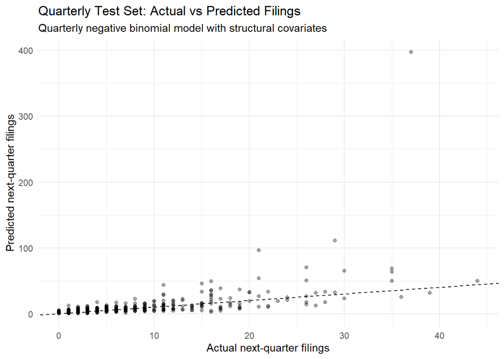

```r
quarterly_test_plot_data <- quarterly_test %>%
  mutate(
    pred_best = predict(quarterly_model_5, newdata = quarterly_test, type = "response")
  ) %>%
  mutate(
    pred_best = pmax(pred_best, 0)
  )

ggplot(quarterly_test_plot_data, aes(x = filings_next, y = pred_best)) +
  geom_point(alpha = 0.35) +
  geom_abline(slope = 1, intercept = 0, linetype = "dashed") +
  labs(
    title = "Quarterly Test Set: Actual vs Predicted Filings",
    subtitle = "Quarterly negative binomial model with structural covariates",
    x = "Actual next-quarter filings",
    y = "Predicted next-quarter filings"
  ) +
  theme_minimal()
```

```r
tidy(quarterly_model_5, conf.int = TRUE, exponentiate = TRUE) %>%
  filter(term != "(Intercept)") %>%
  dplyr::select(term, estimate, conf.low, conf.high, p.value) %>%
  arrange(desc(estimate)) %>%
  mutate(across(c(estimate, conf.low, conf.high, p.value), round, 3)) %>%
  head(15) %>%
  kable(
    caption = "Quarterly Negative Binomial Model Coefficients (Incidence Rate Ratios)",
    col.names = c("Term", "IRR", "Lower CI", "Upper CI", "p-value")
  ) %>%
  kable_styling(bootstrap_options = c("striped", "hover"))
```

Quarterly Negative Binomial Model Coefficients (Incidence Rate Ratios)

| Term | IRR | Lower CI | Upper CI | p-value |
| --- | --- | --- | --- | --- |
| quarter_factorQ3 | 1.281 | 1.158 | 1.417 | 0.000 |
| quarter_factorQ2 | 1.206 | 1.088 | 1.337 | 0.000 |
| quarter_factorQ4 | 1.162 | 1.064 | 1.269 | 0.001 |
| filings_avg | 1.050 | 1.030 | 1.071 | 0.000 |
| lag_1q | 1.034 | 1.026 | 1.043 | 0.000 |
| lag_2q | 1.016 | 1.010 | 1.023 | 0.000 |
| change_1q | 1.011 | 1.004 | 1.018 | 0.002 |
| rent_burden_pct | 1.009 | 1.006 | 1.011 | 0.000 |
| median_household_income | 1.000 | 1.000 | 1.000 | 0.000 |
| median_gross_rent | 1.000 | 1.000 | 1.000 | 0.000 |
| filings_avg_prepandemic_baseline | 0.999 | 0.988 | 1.010 | 0.849 |
| racial_majorityHispanic | 0.941 | 0.822 | 1.079 | 0.377 |
| racial_majorityOther | 0.878 | 0.803 | 0.961 | 0.004 |
| racial_majorityWhite | 0.599 | 0.543 | 0.662 | 0.000 |

```r
quarterly_risk_threshold <- quantile(
  quarterly_train$filings_next_per_1k_renters,
  probs = 0.90,
  na.rm = TRUE
)

quarterly_test_predictions <- quarterly_test %>%
  mutate(
    pred_next = predict(quarterly_model_5, newdata = quarterly_test, type = "response"),
    pred_next_per_1k_renters = (pred_next / renters) * 1000,
    high_risk_true = if_else(filings_next_per_1k_renters >= quarterly_risk_threshold, 1, 0),
    high_risk_pred = if_else(pred_next_per_1k_renters >= quarterly_risk_threshold, 1, 0)
  )

quarterly_risk_scores <- classification_scores(quarterly_test_predictions, "high_risk_true", "high_risk_pred")

quarterly_risk_scores %>%
  mutate(across(everything(), round, 3)) %>%
  kable(caption = "Quarterly High-Risk Classification Performance on Test Data") %>%
  kable_styling(bootstrap_options = c("striped", "hover"))
```

Quarterly High-Risk Classification Performance on Test Data

| Accuracy | Precision | Recall | F1 |
| --- | --- | --- | --- |
| 0.886 | 0.357 | 0.286 | 0.317 |

```r
quarterly_latest_forecast <- quarterly_test_predictions %>%
  filter(quarter_date == max(quarter_date, na.rm = TRUE)) %>%
  arrange(desc(pred_next_per_1k_renters)) %>%
  transmute(
    GEOID,
    racial_majority,
    quarter_label,
    predicted_filings_next_quarter = round(pred_next, 2),
    predicted_rate_next_quarter = round(pred_next_per_1k_renters, 2),
    predicted_high_risk = high_risk_pred
  )

quarterly_latest_forecast %>%
  slice(1:15) %>%
  kable(caption = "Top 15 Tracts by Predicted Next-Quarter Risk") %>%
  kable_styling(bootstrap_options = c("striped", "hover"))
```

Top 15 Tracts by Predicted Next-Quarter Risk

| GEOID | racial_majority | quarter_label | predicted_filings_next_quarter | predicted_rate_next_quarter | predicted_high_risk |
| --- | --- | --- | --- | --- | --- |
| 42101024000 | Black | 2025 Q4 | 397.16 | 250.89 | 1 |
| 42101021800 | White | 2025 Q4 | 111.04 | 61.96 | 1 |
| 42101026800 | Black | 2025 Q4 | 96.51 | 59.87 | 1 |
| 42101012100 | Black | 2025 Q4 | 65.03 | 55.91 | 1 |
| 42101023800 | Black | 2025 Q4 | 68.34 | 46.27 | 1 |
| 42101014100 | Black | 2025 Q4 | 49.79 | 43.45 | 1 |
| 42101024300 | Black | 2025 Q4 | 43.57 | 42.80 | 1 |
| 42101036100 | White | 2025 Q4 | 17.51 | 42.72 | 1 |
| 42101015200 | Black | 2025 Q4 | 63.59 | 39.75 | 1 |
| 42101020101 | Black | 2025 Q4 | 50.35 | 37.08 | 1 |
| 42101027600 | Black | 2025 Q4 | 32.15 | 35.88 | 1 |
| 42101028000 | Black | 2025 Q4 | 19.31 | 35.83 | 1 |
| 42101005500 | Black | 2025 Q4 | 32.18 | 33.00 | 1 |
| 42101011400 | Black | 2025 Q4 | 49.25 | 32.99 | 1 |
| 42101034600 | Other | 2025 Q4 | 33.57 | 32.88 | 1 |

**Summary:** As with the monthly models, MAE and RMSE capture prediction error and correlation reflects the model ability to preserve tract-level ranking. Overall, quarterly performance is weaker (lowest MAE at 3.825 compared to monthly at 1.622), suggesting that aggregation smooths over some of the short-term signal that is useful for forecasting eviction filings.

The quarterly actual-versus-predicted plot appears more dispersed, indicating weaker fit at the tract level. Aggregating to quarterly totals may smooth over some of the short-term signal that improves monthly forecasting performance.

## 4.4 Model Diagnostics

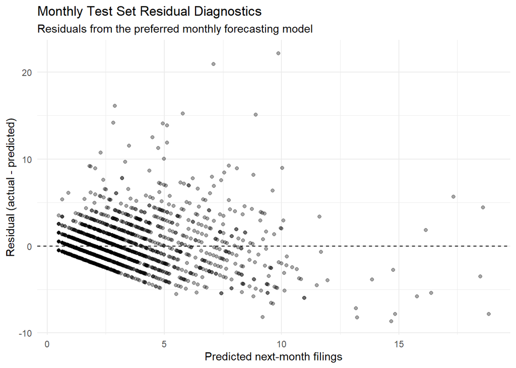

```r
monthly_residual_data <- monthly_test_plot_data %>%
  mutate(
    residual = filings_next - pred_best
  )

ggplot(monthly_residual_data, aes(x = pred_best, y = residual)) +
  geom_point(alpha = 0.35) +
  geom_hline(yintercept = 0, linetype = "dashed") +
  labs(
    title = "Monthly Test Set Residual Diagnostics",
    subtitle = "Residuals from the preferred monthly forecasting model",
    x = "Predicted next-month filings",
    y = "Residual (actual - predicted)"
  ) +
  theme_minimal()
```

**Summary:** Residual diagnostics show that prediction errors become larger at higher predicted filing levels. This suggests that the preferred monthly model is less stable in the highest-risk tracts, which matters for policy use because underpredicting extreme-risk neighborhoods would reduce the effectiveness of early intervention.

# 5 Final Prediction

## 5.1 Selected Forecasting Model

```r
overall_comparison <- bind_rows(
  monthly_scores %>%
    filter(model %in% c("Model 0: Baseline", "Model 0b: + lag_12m baseline", "Model 0c: + rolling_mean_3m baseline", "Model 5: + rent and income")) %>%
    mutate(scale = "Monthly"),
  quarterly_scores %>%
    filter(model %in% c("Model 0: Baseline", "Model 5: + rent and income")) %>%
    mutate(scale = "Quarterly")
) %>%
  mutate(across(c(MAE, RMSE, Correlation), round, 3))

overall_comparison %>%
  dplyr::select(scale, split, model, MAE, RMSE, Correlation) %>%
  kable(caption = "Overall Comparison of Monthly and Quarterly Forecasting Results") %>%
  kable_styling(bootstrap_options = c("striped", "hover"))
```

Overall Comparison of Monthly and Quarterly Forecasting Results

| scale | split | model | MAE | RMSE | Correlation |
| --- | --- | --- | --- | --- | --- |
| Monthly | Validation | Model 0: Baseline | 1.924 | 2.901 | 0.614 |
| Monthly | Validation | Model 0b: + lag_12m baseline | 1.719 | 2.435 | 0.662 |
| Monthly | Validation | Model 0c: + rolling_mean_3m baseline | 1.622 | 2.310 | 0.703 |
| Monthly | Validation | Model 5: + rent and income | 1.983 | 3.679 | 0.599 |
| Monthly | Test | Model 0: Baseline | 1.991 | 3.030 | 0.578 |
| Monthly | Test | Model 0b: + lag_12m baseline | 1.752 | 2.535 | 0.645 |
| Monthly | Test | Model 0c: + rolling_mean_3m baseline | 1.657 | 2.441 | 0.678 |
| Monthly | Test | Model 5: + rent and income | 2.137 | 4.265 | 0.594 |
| Quarterly | Validation | Model 0: Baseline | 3.825 | 5.748 | 0.779 |
| Quarterly | Validation | Model 5: + rent and income | 5.738 | 17.054 | 0.666 |
| Quarterly | Test | Model 0: Baseline | 3.718 | 5.422 | 0.779 |
| Quarterly | Test | Model 5: + rent and income | 5.906 | 20.802 | 0.540 |

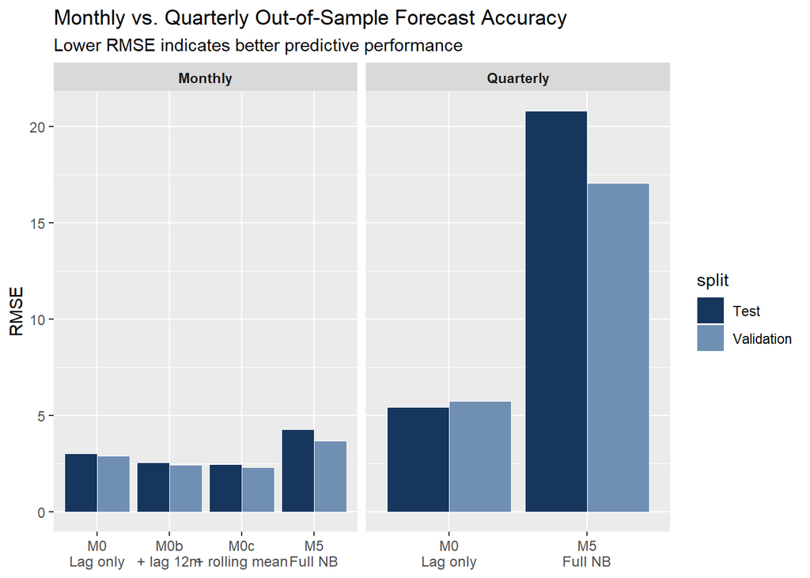

```r
overall_comparison_plot <- overall_comparison %>%
  mutate(
    model_short = case_when(
      model == "Model 0: Baseline" ~ "M0\nLag only",
      model == "Model 0b: + lag_12m baseline" ~ "M0b\n+ lag 12m",
      model == "Model 0c: + rolling_mean_3m baseline" ~ "M0c\n+ rolling mean",
      model == "Model 5: + rent and income" ~ "M5\nFull NB",
      TRUE ~ model
    )
  )

ggplot(overall_comparison_plot, aes(x = model_short, y = RMSE, fill = split)) +
  geom_col(position = "dodge", color = "white", linewidth = 0.2) +
  facet_wrap(~ scale, scales = "free_x") +
  scale_fill_manual(values = c("Validation" = "#6f8fb3", "Test" = "#17365d")) +
  labs(
    title = "Monthly vs. Quarterly Out-of-Sample Forecast Accuracy",
    subtitle = "Lower RMSE indicates better predictive performance",
    x = NULL,
    y = "RMSE"
  ) +
  theme(
    axis.text.x = element_text(size = 9),
    strip.text = element_text(face = "bold")
  )
```

**Summary:** The best model here is **a baseline model with rolling_mean_3m**.

Overall, the evaluation suggests that **monthly forecasting** performs better than quarterly forecasting for predicting future eviction filings. Among the monthly specifications, the **enhanced baseline with lag variables** achieves the strongest out-of-sample performance. This indicate that recent filing history, seasonal recurrence, and short-term persistence are more useful for forecasting than broader structural covariates alone.

At the same time, the richer negative binomial models remain valuable for interpretation. They help explain how tract-level characteristics such as rent burden, income, and neighborhood composition are associated with eviction risk, even if they do not produce the strongest out-of-sample forecasts. For policy purposes, the enhanced monthly baseline is therefore the best option for short-term early-warning and tract prioritization, while the fuller negative binomial model is more useful for understanding structural differences in risk across neighborhoods.

These results suggest that the model should be used as a decision-support tool for prioritizing rental assistance and tenant outreach, not as an automated decision rule or an individual-level targeting system.

# 6 Policy Application

## 6.1 Rental Assistance Targeting

This model supports three complementary policy uses: proactive rental assistance targeting, legal aid allocation, and housing agency early warning.

**Rental assistance targeting.** Monthly tract-level forecasts enable city agencies and nonprofit partners to identify neighborhoods at elevated eviction risk before filings enter the court system. This proactive approach shifts resources upstream—toward emergency rental assistance, tenant counseling, and direct outreach—rather than waiting for households to reach formal proceedings.

**Legal aid allocation.** Legal aid organizations face persistent capacity constraints that prevent uniform coverage across all neighborhoods. Predicted high-risk tracts can guide the deployment of outreach events, mobile legal clinics, and tenant referrals to where demand is likely to peak, maximizing the impact of limited staff resources.

**Early warning dashboard.** Integrated into a monthly dashboard, the model can display predicted filing counts, renter-adjusted risk rates, and high-risk tract flags across Philadelphia. This gives housing agencies a consistent, forward-looking view of where eviction pressure is building and supports timely, coordinated intervention.

## 6.2 Equity and Safeguards

The model must be used exclusively to **expand support for renters**, not to surveil, penalize, or stigmatize high-risk neighborhoods. The data show that Black-majority tracts have higher average eviction filings. This reflects structural inequities in Philadelphia’s housing market, including unequal exposure to rent burden and housing instability. It describes neighborhood-level conditions, not characteristics of individual residents or communities.

Four safeguards should govern any policy deployment:

First, predictions should be restricted to **supportive interventions** like rental assistance, legal aid outreach, tenant counseling, and community-based prevention. The model must not be used for landlord screening, tenant eligibility determinations, code enforcement targeting, or any punitive purpose.

Second, the model should operate **at the census tract level, not the household level**. Tract-level targeting focuses resources on neighborhoods with elevated collective risk, avoiding the harms of labeling individual tenants.

Third, all high-risk tract designations should be **reviewed by housing agencies and community partners** before resources are deployed. Human oversight is especially important given that residual diagnostics show larger prediction errors in high-filing tracts—the neighborhoods most critical for intervention are also the hardest to forecast accurately.

Fourth, the city should **monitor** whether model-informed resources reach the neighborhoods of greatest need. Where the model systematically underpredicts risk or where assistance fails to arrive as planned, both the model and the implementation process should be revised.

# 7 Limitations

## 7.1 Data Limitations

The analysis relies on eviction filing records, which measure court activity rather than completed evictions or the full range of housing instability. Households experiencing informal displacement, “cash for keys” pressure, or severe rent burden without a filed case are not captured. Sealed records are excluded because they lack usable tract identifiers, which may cause undercounting in some areas. Finally, the ACS housing variables are tract-level estimates from a single survey year and do not align perfectly with month-to-month variation in filings.

## 7.2 Model Limitations

The model predicts eviction risk at the census tract level and is not designed for individual-level inference and it should never be used to make decisions about specific tenants or landlords. Although the preferred monthly model outperforms the quarterly specification, it produces larger errors in high-filing tracts, precisely the areas where accurate prediction matters most for intervention. The model captures persistent temporal patterns well, but it cannot fully account for sudden policy shifts, economic shocks, landlord behavior, or household-level circumstances.

## 7.3 Policy Limitations

Predictions alone do not resolve eviction risk. Effective implementation requires adequate rental assistance funding, sufficient legal aid capacity, trusted community partnerships, and timely data updates. There is also a misuse risk: if the model is deployed outside its intended supportive purpose, high-risk labels could be repurposed for exclusion or punitive action. The model should therefore be treated as a decision-support tool for prevention, not as an automated rule for benefit allocation or neighborhood evaluation.

# 8 Conclusion

## 8.1 Technical Takeaways

Recent eviction filing history is the strongest predictor of short-term future filings. Monthly forecasting consistently outperforms quarterly forecasting, as quarterly aggregation obscures short-term temporal signal. Adding structural covariates such as rent burden, household income, and neighborhood composition does not improve out-of-sample performance; in most specifications, it increases prediction error. The negative binomial models with structural covariates are better suited for interpreting why certain tracts carry higher baseline risk than for short-term forecasting.

## 8.2 Policy Takeaways

The model is best used as an early warning tool for rental assistance targeting, legal aid allocation, and housing agency monitoring. It can identify census tracts where eviction pressure is likely to rise, enabling agencies and nonprofit partners to intervene before filings spike. Predictions should be used only to expand supportive services for renters, and must be paired with human review and equity monitoring to ensure resources reach those most in need.